# PSDB_UTS_16231059

### 2.3 Sebaran Jumlah Pieces dan Harga

```
## Warning: Removed 69 rows containing non-finite outside the scale range
## (`stat_smooth()`).
```

```
## Warning: Removed 69 rows containing missing values or values outside the scale range
## (`geom_point()`).
```

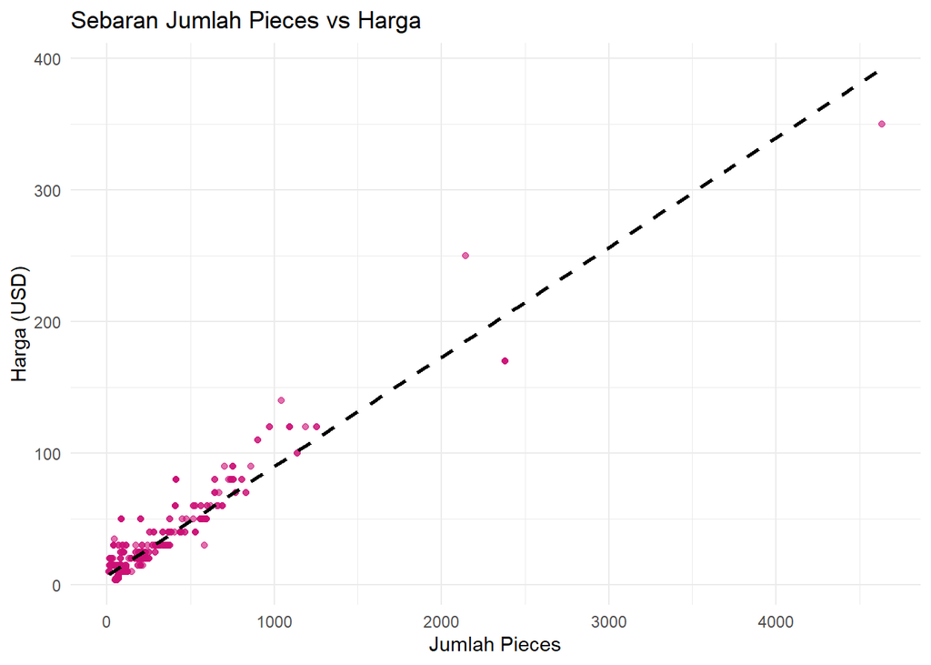

```r
ggplot(lego_sales, aes(x = pieces, y = us_price)) +
  geom_point(alpha = 0.6, color = "deeppink3") +
  geom_smooth(method = "lm", se = FALSE, color = "black", linetype = "dashed") +
  labs(title = "Sebaran Jumlah Pieces vs Harga",
       x = "Jumlah Pieces", y = "Harga (USD)") +
  theme_minimal()
```

Visualisasi di atas merupakan scatter plot yang menunjukkan hubungan antara jumlah pieces (komponen LEGO) dengan harga dalam USD. Sumbu X adalah jumlah pieces, sedangkan sumbu Y adalah harga (USD). Garis linier hitam untuk menunjukkan tren hubungan antar variabel, sehingga visualisasi ini menunjukkan bahwa secara umum terdapat hubungan positif antara jumlah pieces dan harga—semakin banyak pieces, semakin mahal harga lego set tersebut. Hal ini ditunjukkan oleh garis regresi yang mengarah naik. Namun demikian, terdapat beberapa outlier, seperti produk dengan harga tinggi tapi jumlah pieces tidak terlalu banyak. Selain itu, ada warning bahwa 69 baris data dihapus karena memiliki nilai kosong atau di luar rentang skala.

### 2.4 Komposisi Penjualan Berdasarkan Usia

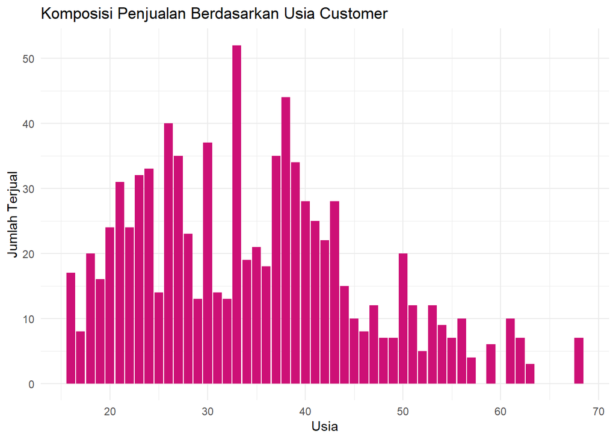

```r
penjualan_usia <- lego_sales %>%
  group_by(age) %>%
  summarise(total_quantity = sum(quantity, na.rm = TRUE))

ggplot(penjualan_usia, aes(x = age, y = total_quantity)) +
  geom_col(fill = "deeppink3") +
  labs(title = "Komposisi Penjualan Berdasarkan Usia Customer",
       x = "Usia", y = "Jumlah Terjual") +
  theme_minimal()
```

Visualisasi di atas merupakan diagram batang menggambarkan jumlah produk lego yang terjual berdasarkan usia customer. Sumbu X adalah usia, sedangkan sumbu Y adalah total jumlah terjual. Data ini diperoleh dari agregasi penjualan berdasarkan usia customer. sehingga visualisasi ini menunjukkan bahwa penjualan tertinggi terjadi pada rentang usia 30-an, dengan puncak penjualan di usia sekitar 33 tahun. Usia 20–40 tahun merupakan kelompok usia yang paling banyak melakukan pembelian lego, sedangkan setelah usia 50 tahun terjadi penurunan signifikan. Hal ini menunjukkan bahwa produk lego paling banyak diminati oleh konsumen dewasa muda hingga usia pertengahan.